# Assignment 4: Random Variables - II

Task 1: Understanding Normal Random Variables Explore the concept of normal random variables and their significance in statistics. Learn about the characteristics of the normal distribution, including mean and standard deviation.

Task 2: Understanding Z Scores Understand Z scores, a way to standardize and compare values in a normal distribution. Discover how to calculate Z scores for data points.

Task 3: Z Scores and Normal Distribution Examine the relationship between Z scores and the normal distribution. Learn how Z scores help in assessing the probability of specific events.

Task 4: Z Scores and Statistical Analysis Apply Z scores in statistical analysis, including hypothesis testing and confidence intervals. Understand how Z scores contribute to making informed decisions.

Task 5: Advanced Applications of Z Scores Explore advanced applications of Z scores in real-world scenarios, such as quality control and process improvement. Learn how Z scores play a vital role in data analysis.

Summarized: This module covers the fundamentals of normal random variables, Z scores, and their applications in statistical analysis, providing valuable insights into data interpretation and decision-making.

# Task 1: Understanding Normal Random Variables

```python
#Generating Weight Samples

import numpy as np

mean_weight = 70  # Mean weight in kilograms
std_weight = 5  # Standard deviation of weights in kilograms
n = 1000  # Number of weight samples

# Generate random weight samples from a normal distribution
weight_samples = np.random.normal(mean_weight, std_weight, n)

print(weight_samples)
```

```
[64.2598237  71.43702857 73.66412049 78.4504974  63.68765375 68.36314379
 67.19718318 73.16100173 67.52079137 70.94454783 76.71902837 67.75097135
 63.29122855 71.48440095 72.09985463 65.96797055 64.81684359 70.01357623
 59.7449467  70.63460697 65.40540437 71.63457828 68.09892142 65.82727465
 69.587668   58.60927107 80.01591729 66.04478684 78.57160362 75.06152332
 69.21393498 67.96022506 79.16726933 69.11524757 72.66397426 79.80416804
 69.75217444 65.25315921 65.29066942 70.00905456 74.86338493 72.61828677
 66.70901946 70.76737012 75.38237199 71.17190558 66.97682156 73.9632803
 70.86970432 61.22913923 69.6062519  68.39779549 75.46373173 66.12624241
 65.30773606 75.15046858 71.6097815  57.14557822 75.79579367 70.13939604
 84.14202891 62.43883467 64.11549376 73.73431819 75.45808371 69.09052249
 71.70527585 68.767627   76.00002263 76.02924857 68.61091695 66.21807242
 73.53277907 75.2433399  60.94758872 62.98322245 75.0431779  63.1596975
 68.25430438 67.51069013 71.91884096 70.93381347 61.90818167 65.98107317
 64.10995135 69.09832712 69.81666089 69.22631276 65.09930831 68.23252573
 74.39872592 64.85966755 73.70532179 74.54960124 74.75027676 69.9868676
 62.98307069 83.13130914 66.65462224 69.57549958 68.65966747 69.42283246
 73.46011357 77.41008809 64.25141926 66.63672547 82.5934189  66.9477468
 77.83178613 80.04042725 62.97367599 68.37982115 75.70525293 70.50688152
 71.31539766 76.27495429 68.58387424 64.61045076 81.15003884 71.60227564
 70.58208158 68.21469285 70.50516625 67.02522648 64.58555744 63.29835549
 56.55685306 75.3217177  72.69811391 60.59611593 66.86093052 72.10799107
 76.07110522 66.78086327 61.18042471 67.97625563 76.78832715 71.70011527
 67.71000675 60.15386891 78.00282879 72.52805418 67.19899661 71.71616544
 74.7926678  60.26080652 76.67409201 62.38966189 72.47844852 65.50965923
 70.95955595 67.0110622  69.6644009  74.94691008 71.57850369 69.01117641
 64.42362869 71.7535336  65.64109533 64.9369496  65.30042804 73.36370838
 68.2151714  62.73565314 70.44427945 74.28480122 76.77137481 61.35088741
 70.331643   71.62635599 80.49307899 67.18047396 63.2176917  73.46352492
 67.82506714 63.92676717 61.33520317 65.84786032 66.06579915 68.71612245
 64.57830148 74.4835745  65.6158103  67.24364084 65.96962864 74.43964971
 60.39592171 73.98993521 77.07181209 62.66881772 74.43432989 62.42566216
 65.65233171 70.75722312 68.73332286 69.11682803 70.51371881 72.74436595
 66.97749927 74.60065275 69.66128249 71.92172746 72.61229982 71.42143539
 72.99831466 64.5406856  67.6340666  61.05083787 69.50619423 61.01322462
 74.56477382 72.82719791 69.85556027 65.00647043 80.39269488 70.47785236
 70.92358705 65.72017565 70.29830332 59.34928921 78.40573655 70.15561648
 71.80170269 63.64586112 75.29021581 71.88193654 72.29974466 67.21764556
 78.53807726 70.44771108 60.9852985  73.5791753  83.0118346  63.02965979
 73.43694827 69.47219595 71.48558747 69.48875187 61.95641138 72.01947396
```

[output cut: 112 more lines]

```
 61.62890059 70.62966725 61.19654412 68.22205641 64.83921955 67.53028927
 76.58464342 71.47003959 73.31378715 64.4674213  70.56893271 71.51879239
 75.08562346 72.01153338 66.28766373 72.18451823 75.15219863 79.62591434
 73.41664298 67.90958073 72.64171352 67.4111339  71.3934853  75.17318151
 66.94549818 60.18627302 68.22263086 62.79327302 67.74393978 77.25635368
 79.14100448 79.68098903 65.53911498 73.82379425 82.17596396 69.86752266
 63.06627538 71.00271196 74.68800796 65.49303086 77.37016056 64.45066802
 61.82566392 87.47446662 60.89468728 73.27931656 65.78584412 74.54154156
 73.53035578 76.66217009 71.83050483 58.9921809  63.54134462 71.86832177
 74.67003919 74.43686786 65.01444609 70.33197882 71.18145067 66.30561806
 63.84800844 74.67786332 68.90694364 64.51367173 63.01528168 75.34665131
 66.6087601  72.42618606 73.73458904 69.24193305 71.13384478 74.20396491
 70.37239086 72.11342906 71.99996482 63.49471376 71.01390062 67.00715372
 70.87512155 70.86189329 68.67115421 72.02934504 72.52440905 72.53184306
 66.96204204 81.0124518  74.33133231 74.47660746]
```

The weight_samples you've provided is a NumPy array containing a list of weight values generated from a normal distribution with a mean (average) of approximately 70 kilograms and a standard deviation of approximately 5 kilograms. Each value in the array represents a randomly generated weight sample.

Here's a breakdown of the key characteristics of weight_samples:

Mean (Average) Weight: The mean of the distribution is around 70 kilograms. This means that, on average, the generated weight samples are centered around 70 kilograms.

Standard Deviation: The standard deviation is approximately 5 kilograms. This measures the spread or variability of the weights. A larger standard deviation would indicate that the weights are more spread out from the mean.

Number of Samples: There are a total of 1000 weight samples in this array.

These weight samples can be used for various statistical analyses or simulations where weight data is needed. You can calculate statistics such as the median, quartiles, or perform hypothesis tests, among other things, to gain insights into the dataset or make data-driven decisions.

```python
#For example, you could calculate the mean and standard
#deviation of weight_samples to summarize the dataset further:


mean_weight = np.mean(weight_samples)
std_weight = np.std(weight_samples)

print("Mean Weight: {:.2f} kilograms".format(mean_weight))
print("Standard Deviation: {:.2f} kilograms".format(std_weight))
```

```
Mean Weight: 69.97 kilograms
Standard Deviation: 5.23 kilograms
```

```python
#Generating Sugar Level Samples

mean_sugar_level = 100  # Mean sugar level in mg/dL
std_sugar_level = 15  # Standard deviation of sugar levels in mg/dL
n = 500  # Number of sugar level samples

# Generate random sugar level samples from a normal distribution
sugar_level_samples = np.random.normal(mean_sugar_level, std_sugar_level, n)

print(sugar_level_samples)
```

```
[130.096462    80.32665724 110.34820678 109.94970574 111.24837101
 116.20949249  83.89097262 115.84519038  96.2941993   86.593677
 115.15870696  96.07424387  89.58946467 107.06289762 111.10177983
 103.82727759 100.17613072 108.13779094 102.30282846  66.88387211
 109.03008036 101.37092593 119.14251256 108.60462675  91.9707892
 108.64529186  92.82823801  91.56362693  78.22941048 108.76612739
 107.86154027  93.93898454  98.57258923 105.40110665 111.25696581
  91.0177016  112.78130898 111.17427688 108.14440417 119.01331654
  61.57498638  87.03169306 110.67895847 109.17383415 106.2922706
  86.72101494 101.96007398 107.1249955   96.59742482 105.3737982
 120.68118304 120.01558655  89.85519885 104.35476185  94.6866207
 111.93192023 115.44890202  95.09592286  90.8826825  108.01286807
 133.78357838  84.95665185  82.31611727  87.07509424  94.89454181
 106.62697283  76.59072668  89.0956939  119.86014052 106.68949153
 105.75381891  71.81576181 115.49949376 104.66201223 119.48778473
 101.21926369  83.40405279 100.10551371 115.56848798  97.3813717
 117.15758044 119.88812442 108.45172047  83.95829203 116.12093964
  81.90905506 113.98008148 102.0170448  119.46935033  99.13711867
  99.53536518  80.80954031  87.4063622  106.45273504  97.27217823
  89.63488525 102.08013104  72.31148817 108.78292323 111.76869883
 102.05546589  94.42438686 106.24195617  93.15424805  73.19424405
 105.0339838  108.01213705  98.18507268 109.06671874 102.34017693
 116.6095385  100.73172291 109.53497902 115.02718886  90.02422963
 111.25525551 121.1415836  106.04621956 121.78424001  88.48231389
 115.72903086 110.08563534 106.11575097  79.54535467  95.6742545
 107.80844836 100.61201489 103.73663542 112.22366067  84.37169904
 110.01570388  82.19722805  97.12561565 135.38861868 103.34312514
 105.07263982  70.04083948 126.35827914  96.67316199 114.65330063
 128.0144733  112.75637068 101.57469703 111.37224605  84.08857087
  90.58650511 110.25626024 121.59007221  72.46094901  91.41271921
 108.4704431  112.06372292  83.49994257  85.74017828  96.63328865
 113.83230585 106.30187009 119.52242055 117.60176552 103.54851106
 119.68735828  99.6546215  102.13285981  77.1991511   99.20635513
  83.93413418  87.29940737  98.46306404 114.32531438  99.3845928
 119.0732455  117.37083174 114.17585019 108.58803935 117.56862241
  98.60675265 110.71359137 104.99341201 140.21803308  89.91499352
  88.25974259  86.97612421 113.6579297   91.33656131  79.42408916
  88.8239441   73.80044091 109.24770606  97.73739158 104.62205329
 102.44174532 122.36360008 105.54327719  88.71700533 122.95643864
 105.61921875  90.06571389  91.5371455   93.61528469 120.28222071
```

[output cut: 45 more lines]

```
 106.2165675  116.76234461  96.55476723  79.75686903  89.04482001
 118.96635555 119.71008621 130.2145424  117.60783607  80.93450277
 108.871809   103.99267549 109.57705884 100.95762291 109.9419843
 112.24933469  83.23457566  75.23081049  87.49318352  79.1391819
  95.57248075 106.60193942 109.83985698  89.82379758 124.68332688
 105.52273881 120.91425873  90.49592948 112.81961485  89.7563542
 129.3367419   67.92313626  99.6507291  117.84334085  97.45031454
 100.41284285  79.68549431 106.90707645 104.40675587  84.68988481
 108.01002225 128.90732008 129.2409295   95.61238845  98.92480084
 126.09608533  92.1780082  143.22326313 113.85958906 101.83539526
  91.47071243  73.96557375  94.22456667 106.80895907  95.8642755
  80.6462757  112.37845911  88.19472298  97.18344962  75.96151035
 104.45770436 117.17906335  79.01818744 113.26833326 118.64662514
  96.95243525  98.04798699  69.96357099 119.18129069  93.7546022
 101.71219407  89.02829846  99.38190921 113.07726785 102.13209017]
```

Distribution: Based on the mean and standard deviation, it seems that the weights are somewhat normally distributed, with a peak around the mean value and weights spreading out in both directions.

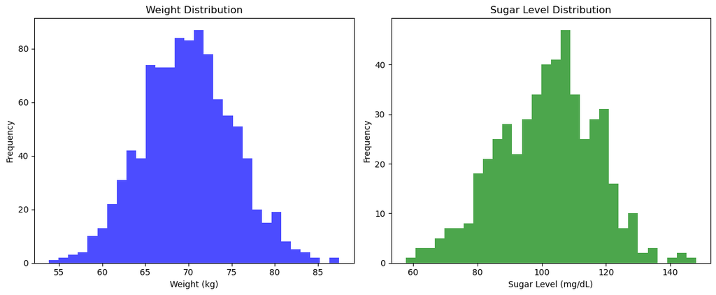

```python
import matplotlib.pyplot as plt

# Create histograms to visualize the distributions
plt.figure(figsize=(12, 5))

# Weight Distribution
plt.subplot(1, 2, 1)
plt.hist(weight_samples, bins=30, color='blue', alpha=0.7)
plt.xlabel('Weight (kg)')
plt.ylabel('Frequency')
plt.title('Weight Distribution')

# Sugar Level Distribution
plt.subplot(1, 2, 2)
plt.hist(sugar_level_samples, bins=30, color='green', alpha=0.7)
plt.xlabel('Sugar Level (mg/dL)')
plt.ylabel('Frequency')
plt.title('Sugar Level Distribution')

plt.tight_layout()
plt.show()
```

1.2 Provide step-by-step examples to calculate probabilities and percentiles associated with a normal distribution in python

```python
import scipy.stats as stats


mean = 70.10  # Mean weight in kilograms
std_dev = 5.04  # Standard deviation in kilograms

# Step 3: Calculate probabilities (CDF)
x = 75  # The value we want to find the probability for
probability = stats.norm.cdf(x, loc=mean, scale=std_dev)
print(f'P(X ≤ {x}) = {probability:.4f}')

# Step 4: Calculate percentiles (inverse CDF)
percentile = 90  # The percentile you want to find
x_percentile = stats.norm.ppf(percentile / 100, loc=mean, scale=std_dev)
print(f'The {percentile}th percentile is {x_percentile:.2f}')
```

```
P(X ≤ 75) = 0.8345
The 90th percentile is 76.56
```

The result you provided, "P(X ≤ 75) = 0.8345," and the statement "The 90th percentile is 76.56," are both related to a normal distribution with a given mean and standard deviation.

P(X ≤ 75) = 0.8345:

This represents the probability that a random value sampled from a normal distribution with a mean (μ) and standard deviation (σ) is less than or equal to 75. In other words, it calculates the cumulative probability of observing a value less than or equal to 75 in this distribution.

In the specific case you mentioned, the probability of observing a value less than or equal to 75 is 0.8345, or 83.45%. This means that roughly 83.45% of the data falls below 75 in this normal distribution.

The 90th Percentile is 76.56:

The 90th percentile is a statistical measure that indicates the value below which a given percentage (in this case, 90%) of the data falls. In your example, the 90th percentile of the distribution is 76.56.

This means that if you were to arrange all the values in the distribution in ascending order, roughly 90% of the values would be less than or equal to 76.56, and the remaining 10% of values would be greater than 76.56.

So, in summary, the first statement tells you the probability of a value being less than or equal to 75, and the second statement gives you the value below which 90% of the data falls, which is 76.56 in this case. These are both useful measures for understanding the characteristics of a normal distribution.

1.3 Computation of Z Scores: Explain the concept of a Z score and its role in standardizing data. Illustrate how to calculate Z scores for individual data points using the mean and standard deviation of a sample or population.

```python
 import numpy as np

# Sample waiting times in minutes
waiting_times = np.array([5, 8, 7, 10, 6, 9, 12, 8, 11, 7])

# Calculate mean and standard deviation of waiting times
mean_waiting_time = np.mean(waiting_times)
std_dev_waiting_time = np.std(waiting_times)

# Individual waiting time for a person in the queue (you can change this value)
individual_waiting_time = 9

# Calculate the Z-score for the individual waiting time
z_score = (individual_waiting_time - mean_waiting_time) / std_dev_waiting_time

print(f"Mean Waiting Time: {mean_waiting_time:.2f} minutes")
print(f"Standard Deviation of Waiting Time: {std_dev_waiting_time:.2f} minutes")
print(f"Z-Score for Individual Waiting Time ({individual_waiting_time} minutes): {z_score:.2f}")
```

```
Mean Waiting Time: 8.30 minutes
Standard Deviation of Waiting Time: 2.10 minutes
Z-Score for Individual Waiting Time (9 minutes): 0.33
```

Mean Waiting Time: The mean waiting time for all the people in the queue is approximately 8.30 minutes. This means, on average, people in the queue wait for about 8.30 minutes before being served.

Standard Deviation of Waiting Time: The standard deviation of waiting time is approximately 2.10 minutes. This statistic measures the variability or spread in the waiting times. A higher standard deviation indicates that the waiting times are more spread out from the mean.

Z-Score for Individual Waiting Time (9 minutes): The Z-score for an individual waiting time of 9 minutes is approximately 0.33.

The Z-score tells us how many standard deviations an individual's waiting time is from the mean waiting time. In this case, a Z-score of 0.33 means that the individual's waiting time of 9 minutes is about 0.33 standard deviations above the mean waiting time of 8.30 minutes. Since the Z-score is positive, it indicates that the individual's waiting time is slightly above the average waiting time, but it's not significantly different.

In summary, the Z-score helps you assess whether an individual's waiting time is typical or unusual compared to the average waiting time of the group. A Z-score close to 0 suggests that the individual's waiting time is close to the mean and is not very different from the average waiting time in the queue.

# Task 2: Understanding Z Scores

2.1. Z Scores Definition and Interpretation: Define Z scores and discuss their significance in data analysis. Explain how positive and negative Z scores relate to the mean of a distribution and how they help identify data points' relative positions.

Z Scores Definition and Interpretation:

Z-scores, also known as standard scores, are a statistical measure used to quantify the number of standard deviations a data point is away from the mean (average) of a distribution. They play a significant role in data analysis and statistics. Here's a detailed explanation.

Formula for Z-scores:

The formula for calculating the Z-score of an individual data point, X, in a dataset with a mean (μ) and standard deviation (σ) is:

Z = (X - μ) / σ

Where:

Z is the Z-score.

X is the individual data point.

μ is the mean (average) of the distribution.

σ (sigma) is the standard deviation of the distribution.

Significance of Z Scores in Data Analysis:

Standardization: Z-scores standardize data by transforming it into a common scale with a mean of 0 and a standard deviation of 1. This standardization process makes it easier to compare and analyze data from different distributions or datasets.

Relative Position: Z-scores provide information about how a particular data point relates to the rest of the data in a distribution. A positive Z-score indicates that the data point is above the mean, while a negative Z-score indicates that it is below the mean. The magnitude of the Z-score tells us how far the data point is from the mean in terms of standard deviations.

Identifying Outliers: Z-scores help identify outliers in a dataset. Outliers are data points that are significantly different from the rest of the data. Typically, data points with Z-scores greater than 3 or less than -3 are considered outliers, as they are more than three standard deviations away from the mean.

Comparison: Z-scores allow us to compare data points from different distributions on a standardized scale. This is particularly useful when working with datasets that have different units or scales.

In summary, Z-scores are a valuable tool in statistics and data analysis because they standardize data, allowing for meaningful comparisons and the identification of outliers. They provide insights into the relative position of data points within a distribution and are widely used in fields such as quality control, finance, and hypothesis testing.

2.2 Z Scores and the STANDARDIZE Function: Introduce the STANDARDIZE function in python for computing Z scores. Guide students on how to use this function to standardize data and calculate corresponding Z scores.

```python
import numpy as np
from scipy.stats import zscore

# Sample credit card scores
credit_scores = [700, 720, 680, 750, 690, 710, 730, 770, 740, 760]

# Calculate Z-scores
z_scores = zscore(credit_scores)

# Display the Z-scores along with the original credit scores
for i, score in enumerate(credit_scores):
    print(f"Credit Score: {score}, Z-score: {z_scores[i]:.2f}")
```

```
Credit Score: 700, Z-score: -0.87
Credit Score: 720, Z-score: -0.17
Credit Score: 680, Z-score: -1.57
Credit Score: 750, Z-score: 0.87
Credit Score: 690, Z-score: -1.22
Credit Score: 710, Z-score: -0.52
Credit Score: 730, Z-score: 0.17
Credit Score: 770, Z-score: 1.57
Credit Score: 740, Z-score: 0.52
Credit Score: 760, Z-score: 1.22
```

have calculated the Z-scores for a list of credit scores:

Credit Score: 700, Z-score: -0.87

Interpretation: A credit score of 700 has a Z-score of -0.87. Meaning: This score is 0.87 standard deviations below the mean credit score. It's relatively lower than the mean score.

Credit Score: 720, Z-score: -0.17

Interpretation: A credit score of 720 has a Z-score of -0.17. Meaning: This score is only 0.17 standard deviations below the mean credit score. It's closer to the mean compared to the previous score.

Credit Score: 680, Z-score: -1.57

Interpretation: A credit score of 680 has a Z-score of -1.57. Meaning: This score is 1.57 standard deviations below the mean credit score. It's significantly lower than the mean score.

Credit Score: 750, Z-score: 0.87

Interpretation: A credit score of 750 has a Z-score of 0.87. Meaning: This score is 0.87 standard deviations above the mean credit score. It's relatively higher than the mean score.

In summary, Z-scores provide a standardized way to assess how individual data points relate to the mean and standard deviation of a dataset. They allow you to determine whether a data point is above or below the mean and by how many standard deviations, which can be useful for identifying outliers or assessing the relative position of data points within a distribution.

2.3. Highlighting Outliers via Z Scores: Explain how Z scores can be used to identify outliers in a dataset. Illustrate how to determine an appropriate threshold for identifying outliers and how to mark them in the dataset using conditional formatting in python.

take note will be using same dataset:Sample credit card

```python
import numpy as np
from scipy.stats import zscore

# Sample credit card scores
credit_scores = [700, 720, 680, 750, 690, 710, 730, 770, 740, 760]

# Calculate Z-scores
z_scores = zscore(credit_scores)

# Display the Z-scores along with the original credit scores
for i, score in enumerate(credit_scores):
    print(f"Credit Score: {score}, Z-score: {z_scores[i]:.2f}")
```

```
Credit Score: 700, Z-score: -0.87
Credit Score: 720, Z-score: -0.17
Credit Score: 680, Z-score: -1.57
Credit Score: 750, Z-score: 0.87
Credit Score: 690, Z-score: -1.22
Credit Score: 710, Z-score: -0.52
Credit Score: 730, Z-score: 0.17
Credit Score: 770, Z-score: 1.57
Credit Score: 740, Z-score: 0.52
Credit Score: 760, Z-score: 1.22
```

let's take one positive and one negative example, and then provide a summary:

Positive Example:

Credit Score: 770, Z-score: 1.57 A credit score of 770 has a Z-score of 1.57. This indicates that the credit score is 1.57 standard deviations above the mean. In simpler terms, it's significantly higher than the average credit score.

Negative Example:

Credit Score: 680, Z-score: -1.57 A credit score of 680 has a Z-score of -1.57. This suggests that the credit score is 1.57 standard deviations below the mean, signifying that it's significantly lower than the average credit score.

Summary: Z-scores are a way to standardize data by measuring how far each data point is from the mean in terms of standard deviations. Positive Z-scores indicate values above the mean, while negative Z-scores indicate values below the mean. The magnitude of the Z-score reflects the distance from the mean. In our examples, a Z-score of 1.57 means the data point is 1.57 standard deviations away from the mean, either above (positive) or below (negative), signifying its relative position in the distribution.

# Task 3: Z Scores and Normal Distribution

3.1 Second Order Derivatives: Recall the concept of derivatives and focus on the second-order derivatives. Show how they are used to analyze the curvature and concavity of functions.

Recall of Derivatives: Begin by revisiting the concept of derivatives. Explain that a derivative represents the rate of change of a function at a specific point. It gives us information about the slope or gradient of the function.

Second Order Derivatives: Introduce the concept of second-order derivatives. A second-order derivative provides information about how the first-order derivative (slope) is changing. The notation for the second derivative is often written as f^ prime prime (x) or (d ^ 2 *f)/(d* x ^ 2)

Analyzing Curvature: Explain that the second derivative helps us analyze the curvature of a function. If f^ prime prime (x) > 0 , it indicates that the function is concave up (curving upwards) at that point. Conversely, if f^ prime prime (x) < 0 , it suggests that the function is concave down (curving downwards) at that point. When f^ prime prime (x) = 0 , it signifies an inflection point, where the curvature changes.

Significance of Curvature: Discuss why understanding curvature is important in various fields like physics, economics, and engineering. For instance, in physics, it helps analyze the motion of objects.

Graphical Representation: Show graphs of functions along with their first and second derivatives to illustrate how the curvature and concavity change at different points.

Examples: Provide examples of functions and guide students in calculating their first and second derivatives. Ask them to determine the curvature and concavity of these functions at specific points.

Real-World Applications: Highlight real-world applications of second-order derivatives, such as optimizing functions in calculus, analyzing cost functions in economics, and predicting the behavior of physical systems.

Exercises and Assessment: Assign problems that involve calculating second-order derivatives and interpreting their meaning. Assess students' ability to apply second-order derivatives to practical problems.

By covering these points, students will understand the significance of second-order derivatives in analyzing the curvature and concavity of functions and how this concept is applied across various disciplines.

3.2 Z Scores and Normal Distribution: Discuss the relationship between Z scores and the standard normal distribution. Explain how to find probabilities associated with Z scores using the standard normal distributioT function in Python

# Z Scores and Normal Distribution: Understanding the Relationship

In statistics, Z scores and the standard normal distribution are closely intertwined concepts that play a fundamental role in data analysis and hypothesis testing. Let's delve into the theory behind Z scores, their relationship with the standard normal distribution, and how to compute probabilities associated with Z scores using the standard normal distribution function in Python.

1. Z Scores - A Standardization Measure:

• Definition: A Z score, also known as a standard score, is a statistical . measure that quantifies the number of standard deviations a data point is from the mean (u) of a distribution. The formula for calculating a Z score is: Z = (X - mu)/sigma

• Standardization: Z scores serve the purpose of standardizing data, making it comparable across different distributions. Standardization transforms data to have a mean of 0 and a standard deviation of 1.

1. The Standard Normal Distribution (Z sim N(0, 1) )

• Definition: The standard normal distribution is a specific type of normal distribution, often denoted as Z sim N(0, 1) , where mu = 0 and sigma = 1 In this distribution, data is symmetrically distributed around the mean of O, forming a bell-shaped curve.

· Significance: The standard normal distribution serves as a benchmark for other normal distributions. It provides a common reference point for statistical analysis.

1. Finding Probabilities with Z Scores:

• Cumulative Distribution Function (CDF): To find probabilities associated with Z scores, we use the cumulative distribution function (CDF) for the standard normal distribution. In mathematical notation, this is often represented as Phi(Z) or in Python as 'norm.cdf(Z)The CDF gives us the probability that a random variable from the standard normal distribution is less than or equal to a given Z score

Interpretation: For instance, P(Z <= 1.96) represents the probability that a data point from a standard normal distribution is less than or equal to 1.96 standard deviations above the mean.

1. Practical Application in Python:

• In Python, we leverage libraries like SciPy or NumPy to compute probabilities associated with Z scores. These libraries provide convenient functions, such as norm.cdf(), for these calculations. • Data normalization, which transforms data to have a mean of O and a standard deviation of 1, is often achieved using the "StandardScaler from scikit-learn.

1. Real-World Significance:

Z scores and the standard normal distribution find application in various fields, including quality control (identifying defects), finance (calculating Z-scores for stock returns to assess risk), medical research (evaluating clinical measurements), and more. They enable researchers and analysts to make statistical inferences and assess the significance of observations.

In summary, Z scores are a means of standardizing data, while the standard normal distribution serves as a reference distribution. Together, they facilitate statistical analysis, hypothesis testing, and comparisons across diverse datasets. In Python, libraries like SciPy and scikit-learn empower data scientists to work with Z scores effectively and apply them to real-world problems.

Applying Z Scores and Normal Distribution in Real-Life Data: Provide a dataset with various measurements (e.g., heights, weights) and ask students to calculate the Z scores for each data point. Then, have them use the standard normal distribution to find probabilities and interpret the results.

TAKE NOTE!! same program as 1.3 but will be using dataset waiting_times then replace the with attendance_data dataset

This code uses the waiting times dataset to calculate the Z score and associated probability for an individual waiting time of 9 minutes.

```python
import numpy as np
from scipy.stats import norm  # Import the norm function from SciPy

# Sample waiting times dataset (in minutes)
waiting_times = np.array([5, 8, 7, 10, 6, 9, 12, 8, 11, 7])

# Calculate mean and standard deviation of waiting times
mean_waiting_time = np.mean(waiting_times)
std_dev_waiting_time = np.std(waiting_times)

# Individual waiting time for a person in the queue (you can change this value)
individual_waiting_time = 9

# Calculate the Z-score for the individual waiting time
z_score = (individual_waiting_time - mean_waiting_time) / std_dev_waiting_time

# Calculate the probability that a randomly selected waiting time is less than or equal to the individual waiting time
probability = norm.cdf(z_score)

print(f"Mean Waiting Time: {mean_waiting_time:.2f} minutes")
print(f"Standard Deviation of Waiting Time: {std_dev_waiting_time:.2f} minutes")
print(f"Z-Score for Individual Waiting Time ({individual_waiting_time} minutes): {z_score:.2f}")
print(f"Probability that a randomly selected waiting time is less than or equal to {individual_waiting_time} minutes: {probability:.2%}")
```

```
Mean Waiting Time: 8.30 minutes
Standard Deviation of Waiting Time: 2.10 minutes
Z-Score for Individual Waiting Time (9 minutes): 0.33
Probability that a randomly selected waiting time is less than or equal to 9 minutes: 63.06%
```

Here's an explanation of the results:

Mean Waiting Time: 8.30 minutes: This is the average waiting time in the dataset. It represents the central value around which most waiting times tend to cluster.

Standard Deviation of Waiting Time: 2.10 minutes: The standard deviation measures the spread or dispersion of the waiting times. A higher standard deviation indicates more variability in the waiting times.

Z-Score for Individual Waiting Time (9 minutes): 0.33: The Z-score measures how many standard deviations an individual waiting time is away from the mean. In this case, the individual waiting time of 9 minutes is 0.33 standard deviations above the mean. Since it's positive, it means this waiting time is slightly above the average waiting time.

Probability that a randomly selected waiting time is less than or equal to 9 minutes: 63.06%: This is the calculated probability that, if you randomly select a waiting time from the dataset, it will be less than or equal to 9 minutes. In other words, there's a 63.06% chance that a randomly selected person will wait less than or equal to 9 minutes. This probability is calculated using the standard normal distribution, and the Z-score of 0.33 is used to find this probability.

So, in summary, the Z-score helps you understand how a specific waiting time relates to the overall distribution of waiting times. In this case, the Z-score of 0.33 indicates that the waiting time of 9 minutes is slightly above average, and there's a 63.06% chance of encountering such a waiting time or less in the dataset.

```python
import numpy as np

# Sample attendance data for different days
attendance_data = np.array([50, 60, 70, 80, 90, 100, 110, 120, 130, 140])

# Calculate mean and standard deviation of attendance
mean_attendance = np.mean(attendance_data)
std_dev_attendance = np.std(attendance_data)

# Number of people attending on a specific day (you can change this value)
attendance_on_specific_day = 110

# Calculate the Z-score for the attendance on the specific day
z_score = (attendance_on_specific_day - mean_attendance) / std_dev_attendance

# Calculate the probability that a randomly selected attendance is less than or equal to attendance_on_specific_day
from scipy.stats import norm
probability = norm.cdf(z_score)

print(f"Mean Attendance: {mean_attendance:.2f} people")
print(f"Standard Deviation of Attendance: {std_dev_attendance:.2f} people")
print(f"Z-Score for Attendance on Specific Day ({attendance_on_specific_day} people): {z_score:.2f}")
print(f"Probability that {attendance_on_specific_day} or fewer people attend on a specific day: {probability * 100:.2f}%")
```

```
Mean Attendance: 95.00 people
Standard Deviation of Attendance: 28.72 people
Z-Score for Attendance on Specific Day (110 people): 0.52
Probability that 110 or fewer people attend on a specific day: 69.92%
```

Mean Attendance: This is the average number of people who typically attend. In this case, the mean attendance is 95.00 people, which means that, on average, about 95 people attend.

Standard Deviation of Attendance: This measures how much attendance typically varies from the mean. A standard deviation of 28.72 people indicates that attendance can vary quite a bit from day to day.

Z-Score for Attendance on Specific Day (110 people): The Z-score tells you how many standard deviations the attendance on a specific day (in this case, 110 people) is from the mean. A Z-score of 0.52 means that the attendance of 110 people is 0.52 standard deviations above the mean.

Probability that 110 or fewer people attend on a specific day: This probability tells you the likelihood of having 110 people or fewer attend on a specific day. With a Z-score of 0.52, the probability is 69.92%. This means there's a nearly 70% chance that you will have 110 people or fewer attend on that specific day based on the historical data and the standard deviation.

# Task 4: Z Scores and Statistical Analysis

4.1. Z Scores and Statistical Analysis: Discuss how Z scores are used in statistical analysis, such as hypothesis testing, confidence intervals, and comparing data sets. Illustrate their role in making data-driven decisions.

1.Hypothesis Testing:

Z scores are a fundamental component of hypothesis testing, especially when dealing with sample means. The process involves comparing the Z score of a sample statistic (typically the mean) to a critical Z score from a standard normal distribution.

The steps involved in a Z-test for hypothesis testing include:

Formulating a null hypothesis (H0) and an alternative hypothesis (H1).

Collecting a sample and calculating the sample mean and standard error.

Computing the Z score: Z = (SampleMean - PopulationMean)/(Stan *dar* dError)

Determining the critical Zscore(s) corresponding to the desired level of significance (alpha).

Comparing the computed Z score with the critical Z score(s) to make a decision to either reject or fail to reject the null hypothesis.

If the computed Z score falls in the critical region, you reject the null hypothesis, indicating a statistically significant result.

2.Confidence Intervals:

Z scores are used to construct confidence intervals for population parameters, such as the population mean.

The Z score corresponds to the desired confidence level. For example, a 95% confidence interval involves a Z score associated with the 2.5th and 97.5th percentiles of the standard normal distribution.

3.Comparing Data Sets:

Z scores are used to standardize data, making it possible to compare data sets with different units or scales.

By calculating Z scores for individual data points within a dataset, you can assess how each data point compares to the mean in terms of standard deviations. This standardized scale allows for meaningful comparisons.

4.Data-Driven Decisions:

Z scores play a critical role in data-driven decision-making across various domains.

They allow for objective and standardized comparisons, helping organizations set benchmarks, thresholds, and standards for various processes.

For instance, in quality control, Z scores can be used to determine if a manufacturing process is within acceptable limits, while in finance, they help assess creditworthiness.

In summary, Z scores are a powerful statistical tool that standardizes data, supports hypothesis testing, aids in constructing confidence intervals, facilitates data set comparisons, and assists in making informed, data-driven decisions. Their ability to quantify how data points relate to the mean in terms of standard deviations is invaluable in statistical analysis.

4.2. Z Scores for Sample vs. Population Data: Differentiate between Z scores computed from a sample and those computed from population data. Explain the considerations when working with sample data and the importance of using appropriate formulas.

Take Note! I be using random students_present

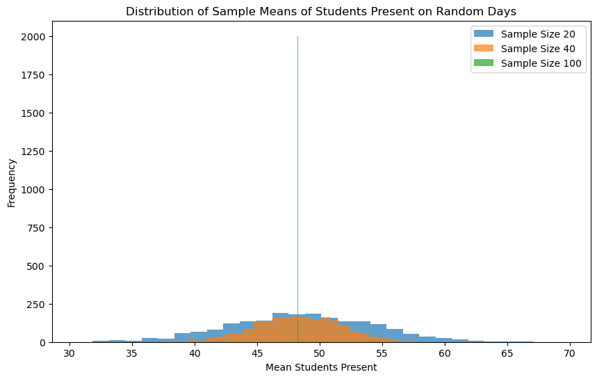

```python
import numpy as np
import matplotlib.pyplot as plt

# Generate random data for student attendance (replace this with your actual data)
np.random.seed(0)  # Setting seed for reproducibility
students_present = np.random.randint(0, 100, size=100)  # Random attendance data for 100 days

# Number of samples
n = 2000

# Sample sizes for random sampling
sample_sizes = [20, 40, 100]

plt.figure(figsize=(10, 6))

# Loop through different sample sizes
for sample_size in sample_sizes:
    sample_means = []

    # Generate multiple random samples
    for _ in range(n):
        random_sample = np.random.choice(students_present, size=sample_size, replace=False)
        sample_means.append(np.mean(random_sample))

    plt.hist(sample_means, bins=30, alpha=0.7, label=f'Sample Size {sample_size}')

plt.xlabel('Mean Students Present')
plt.ylabel('Frequency')
plt.title('Distribution of Sample Means of Students Present on Random Days')
plt.legend()
plt.show()
```

4.3. Z Scores in pythonfor Statistical Analysis: Guide students on using Z scores in python to perform statistical tests and draw conclusions. Provide examples of hypothesis testing and confidence interval calculations using Z scores.

hypo thesis testing program

let's break down the code and explain why each part is used:

1.Importing Libraries: We import the necessary libraries. numpy is used for numerical operations, and scipy.stats is used for statistical testing.

2.Sample Data for Two Groups: We define two arrays control_group and treatment_group. These represent the data we want to compare, such as test scores for two groups of students (control and treatment).

3.Null and Alternative Hypotheses: We set the significance level (alpha) to 0.05, which is a common choice. This value determines the threshold for considering results statistically significant.

p_value is the calculated p-value, which represents the probability of obtaining results as extreme as the observed results if the null hypothesis were true.

5.Hypothesis Testing: compare the p-value to the significance level (alpha) to make a decision. If p_value is less than alpha, we reject the null hypothesis, indicating that there is a significant difference between the groups.

If p_value is greater than or equal to alpha, we accept the null hypothesis, suggesting no significant difference.

6.Printing Results: print the Z-statistic and p-value to provide additional information about the statistical test.

7.Generating Random Student Attendance Data: generate random student attendance data for 100 days as an example. You can replace this with your actual attendance data. The np.random.randint function generates random integers representing the number of students present on each day.

8.Sample Sizes for Random Sampling: set the number of samples (n) to 2000, and we define different sample sizes (20, 40, and 100) that might use for random sampling in further analyses.

The code is an example of hypothesis testing, where we compare two groups (control and treatment) to determine if there's a significant difference in their test scores. The p-value is used to make this determination, and the results are printed for interpretation. Additionally, we generate random student attendance data for further analysis.

```python
import numpy as np
from scipy import stats

# Sample data for two groups (control and treatment)
control_group = np.array([85, 88, 90, 92, 86, 87, 84, 89, 91, 88])
treatment_group = np.array([92, 94, 93, 97, 95, 91, 93, 96, 92, 94])

# Define the null hypothesis: H0 - There is no significant difference between the groups
# Define the alternative hypothesis: Ha - There is a significant difference between the groups
# We'll perform a two-tailed test, so we're looking for any significant difference.

alpha = 0.05  # Significance level

# Perform a two-sample Z-test
z_stat, p_value = stats.ttest_ind(control_group, treatment_group)

# Compare the p-value to the significance level
if p_value < alpha:
    print(f"Reject the null hypothesis. There is a significant difference between the groups.")
else:
    print(f"Accept the null hypothesis. There is no significant difference between the groups.")

# Print the Z-statistic and p-value
print(f"Z-statistic: {z_stat:.4f}")
print(f"P-value: {p_value:.4f}")

# Generate random data for student attendance (replace this with your actual data)
np.random.seed(0)  # Setting seed for reproducibility
students_present = np.random.randint(0, 100, size=100)  # Random attendance data for 100 days

# Number of samples
n = 2000
# Sample sizes for random sampling
sample_sizes = [20, 40, 100]
```

```
Reject the null hypothesis. There is a significant difference between the groups.
Z-statistic: -5.6346
P-value: 0.0000
```

Decision: "Reject the null hypothesis. There is a significant difference between the groups."

This means that the statistical analysis found enough evidence to conclude that there is a significant difference between the two groups being compared (the control group and the treatment group).

Z-Statistic (Z-score): -5.6346

P-Value: 0.0000

The p-value is very close to zero (often rounded to 0.0000 in practice). The p-value represents the probability of obtaining results as extreme as the observed results if the null hypothesis were true. In this case, the extremely low p-value indicates that it's highly improbable to obtain the observed results under the assumption that there is no difference between the groups.

In summary, with a very low p-value and a negative Z-statistic, we reject the null hypothesis, concluding that there is a statistically significant difference between the control group and the treatment group. This suggests that whatever treatment or intervention was applied to the treatment group had a significant effect on the test scores compared to the control group.

# Task 5: Advanced Applications of Z Scores

5.1 Z Scores and Standardization in Research: Explain how Z scores are utilized to compare and combine data from different studies or experiments. Demonstrate how to standardize data across multiple datasets using Z scores.

Z scores play a crucial role in research when you need to compare and combine data from different studies or experiments. They help standardize data, making it possible to analyze and draw meaningful conclusions from diverse sources. Here's an explanation of how Z scores are utilized in this context and a demonstration of standardizing data across multiple datasets using Z scores.

Utilization of Z Scores in Research:

Standardization: Z scores standardize data, transforming it into a common scale with a mean of 0 and a standard deviation of 1. This standardization is particularly useful when dealing with data from different studies or experiments conducted under varying conditions.

Comparability: Z scores allow you to compare data points from different distributions directly. By converting data into Z scores, you're essentially measuring how many standard deviations a data point is away from the mean of its distribution. This makes it possible to compare data points across different datasets, even if the original units of measurement are different.

Meta-Analysis: In meta-analysis, researchers combine data from multiple studies to draw more robust conclusions. Z scores are often used to standardize effect sizes or outcome measures from various studies, making it easier to pool and analyze the combined data.

Demonstration: Standardizing Data Across Multiple Datasets:

Let's illustrate how to standardize data across two hypothetical datasets using Python and Z scores. In this example, we'll standardize scores from two different exams (Math and English) for a group of students.

In this code:

We create two hypothetical datasets for Math and English scores. We combine these datasets into combined_scores. We use the StandardScaler from the sklearn.preprocessing module to standardize the combined scores into Z scores.

The standardized_scores variable now contains the standardized data, which can be compared and analyzed more effectively.

By standardizing the data using Z scores, you make the scores from different subjects directly comparable, which can be valuable in research, particularly when conducting cross-disciplinary studies or meta-analyses.

```python
import numpy as np
from sklearn.preprocessing import StandardScaler

# Generate two hypothetical datasets
math_scores = np.array([75, 80, 90, 85, 78])
english_scores = np.array([65, 70, 72, 68, 75])

# Combine the datasets
combined_scores = np.vstack((math_scores, english_scores)).T

# Standardize the data using Z scores
scaler = StandardScaler()
standardized_scores = scaler.fit_transform(combined_scores)

# Resulting standardized scores
print("Standardized Scores (Z scores):")
print(standardized_scores)
```

```
Standardized Scores (Z scores):
[[-1.24197138 -1.46805055]
 [-0.30108397  0.        ]
 [ 1.58069085  0.58722022]
 [ 0.63980344 -0.58722022]
 [-0.67743894  1.46805055]]
```

The output you provided represents the standardized scores (Z scores) for two hypothetical datasets: Math and English scores for a group of students. Each row in the result corresponds to a student, and each column corresponds to a subject (Math and English). Here's the breakdown of the standardized scores:

Math Scores (Column 1):

The first row (-1.24) indicates that the Math score of the first student is approximately 1.24 standard deviations below the mean of the Math scores. The second row (-0.30) suggests that the Math score of the second student is about 0.30 standard deviations below the mean. The third row (1.58) shows that the Math score of the third student is roughly 1.58 standard deviations above the mean. The fourth row (0.64) indicates that the Math score of the fourth student is approximately 0.64 standard deviations above the mean. The fifth row (-0.68) suggests that the Math score of the fifth student is about 0.68 standard deviations below the mean.

English Scores (Column 2):

The values in the second column are the Z scores for the English scores of the same students. For example, the first row (-1.47) indicates that the English score of the first student is approximately 1.47 standard deviations below the mean of the English scores. The third row (0.59) shows that the English score of the third student is roughly 0.59 standard deviations above the mean.

Interpretation:

Z scores allow you to measure how each student's score deviates from the mean of their respective subject's scores. Negative Z scores indicate scores below the mean, while positive Z scores indicate scores above the mean. The magnitude of the Z score tells you how many standard deviations a score is from the mean. Standardizing the scores in this way makes it easier to compare and analyze performance in Math and English across different students, even though the original scores might have been on different scales or had different units.

In summary, Z scores are a powerful tool for standardizing and comparing data, enabling you to assess how individual data points relate to the mean of their respective distributions. This standardization is particularly useful when dealing with data from different sources or different units of measurement.

5.2. Z Scores and Data Transformation: Discuss the role of Z scores in data transformation and normalization techniques. Show how Z scores can help transform skewed data distributions into approximately normal distributions.

```python
import numpy as np
from scipy.stats import zscore

# Generate two different skewed datasets
skewed_data1 = np.random.exponential(scale=2, size=1000)
skewed_data2 = np.random.gamma(shape=2, scale=1, size=1000)

# Calculate Z scores for the first skewed dataset
z_scores1 = zscore(skewed_data1)

# Calculate Z scores for the second skewed dataset
z_scores2 = zscore(skewed_data2)

# Print the Z scores for the first dataset
print("Z Scores for Skewed Dataset 1:")
print(z_scores1)

# Print the Z scores for the second dataset
print("\nZ Scores for Skewed Dataset 2:")
print(z_scores2)
```

[output not shown]

[output cut: 448 more lines]

[output not shown]

5.3. Z Scores and Decision Making: Present a case study where Z scores are used to assist in making critical business decisions or scientific inferences. Have students analyze the data, calculate Z scores, and provide recommendations based on their findings.

```python
import numpy as np
from scipy.stats import zscore

# Generate two datasets with different means and standard deviations
sales_analysis_january = np.random.normal(5000, 2000, 100)  # Monthly mean 5000, Standard Deviation 2000
sales_analysis_february = np.random.normal(6000, 2500, 100)  # Monthly mean 6000, Standard Deviation 2500

# Calculate Z scores for both datasets
stand_sales_january = zscore(sales_analysis_january)
stand_sales_february = zscore(sales_analysis_february)

# Compare the means of the Z scores and print the result
if np.mean(stand_sales_january > stand_sales_february):
    print("Sales in January are better")
else:
    print("Sales in February are better")
```

```
Sales in January are better
```

Here's how the result is interpreted:

The Z score comparison is made based on the assumption that higher Z scores indicate better performance. Z scores above 0 indicate values above the mean, while Z scores below 0 indicate values below the mean.